# Introduction to Computational Finance

# Optimal Portfolios

In this series we deal with the closing prices of Macdonald’s, Bank of America, IBM,Chevron, Coca-Cola, Novartis and AT&T, over a one-year time span extending from 2013-05-01 to 2014-05-01. Using the data available on Moodle, draw Markowitz’s efficient frontier using on the one hand the analytical expression, and on the other a random Monte-Carlo search. Using the efficient frontier, find the weight of the portfolio with the minimal volatility. What can you say about the return of this portfolio?

# methode_monte_carlo:

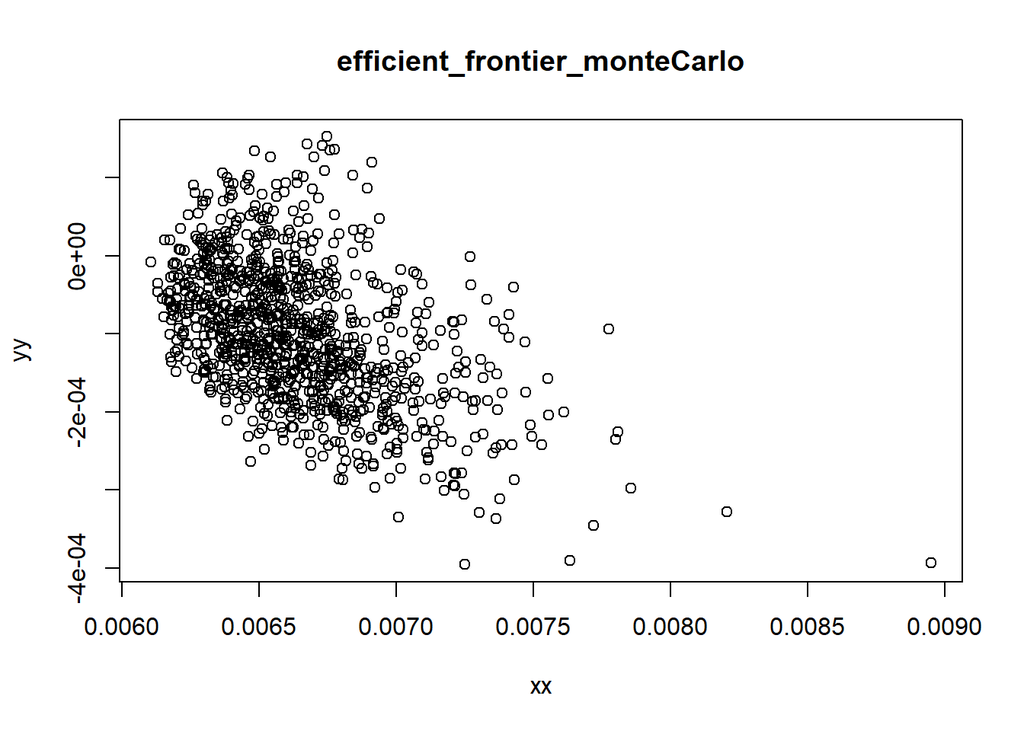

```r
mafct <- function(data) {
poids<-prop.table(runif(7))
ret<-data[-1,]
for (i in 1:nrow(ret)){
  for (j in 1:ncol(ret)){
    ret[i,j]<-(ret[i,j]-data[i,j])/data[i,j]
  }
}
C <- var(ret,na.rm = T)
esperance_retours<-colMeans(ret)
multip_ret<-replicate(7,1)
for (i in 1:nrow(ret)) {
   multip_ret<-multip_ret*(1+ret[i,])
   }
portfolio_esp_tab<-poids*esperance_retours
portfolio_esp<-sum(portfolio_esp_tab)
portfolio_var<-0
for (i in 1:nrow(C)) {
  for (j in 1:ncol(C)) {
    portfolio_var<-portfolio_var+poids[i]*poids[j]*C[i,j]
  }
}

portfolio_sigma=sqrt(portfolio_var)
temp<- list(mu_p=as.numeric(portfolio_esp),sqrt_var_p=as.numeric(portfolio_sigma))
return (temp)
}

data <- read.table("closes.dat",
                   col.names = c("mcdo","boa","ibm","ch","coca","nov","att"));
N=1000
xx<-0
yy<-0
for (i in 1:N){
  r<-mafct(data)
  xx<-c(xx,r$sqrt_var_p)
  yy<-c(yy,r$mu_p)
}
xx<-xx[-1]
yy<-yy[-1]
plot(xx, yy,
     main="efficient_frontier_monteCarlo",
     xxlab="sigma_p",
     yylab="E(R_p)")
```

# methode_analytique_plusPlots:

```r
data <- read.table("closes.dat",
                   col.names = c("mcdo","boa","ibm","ch","coca","nov","att"));

mafct2 <- function(data) {
means <- colMeans(data,na.rm = T) #vest 1,7 qui contient les moyennes
C <- var(data,na.rm = T) #matric de cov
invC <- solve(C) #inverse la matrice

un <- matrix(1, nrow = length(means))


alpha <- t(un) %*% invC %*% un #oy t(..) est la transposee
beta <- t(un) %*% invC %*% means
gamma <- t(means) %*% invC %*% means
delta <- alpha * gamma - beta * beta

a = as.numeric(alpha)
b = as.numeric(beta)
c = as.numeric(gamma)
d = as.numeric(delta)

weights <- prop.table((runif(7)))
mu_p<-sum(weights*means)

lambd1<-(c-b*mu_p)/d
lambd2<-(a*mu_p-b)/d

w <- invC%*%t((lambd1*t(un)+lambd2*means))
sigma_p_sq <- t(w)%*%C%*%w
#test<-lambd1+lambd2*mu_p
temp<- list(mu_p=as.numeric(mu_p),var_p=as.numeric(sigma_p_sq),poids=c(weights))
return (temp)
}
ret<-data[-1,]
for (i in 1:nrow(ret)){
  for (j in 1:ncol(ret)){
    ret[i,j]<-(ret[i,j]-data[i,j])/data[i,j]
  }
}
N=10000
x<-0
y<-0
w<-prop.table((runif(7)))
for (i in 1:N){
  r<-mafct2(ret)
  x<-c(x,r$var_p)
  y<-c(y,r$mu_p)
  w<-c(w,r$poids)
}
x<-x[-1]
y<-y[-1]
w<-w[-1]
w<-w[-1]
w<-w[-1]
w<-w[-1]
w<-w[-1]
w<-w[-1]
w<-w[-1]

plot(x, y,
     main="efficient_frontier_avecmin",
     xlab="sigma_p",
     ylab="E(R_p)",
     #ylim = c(-1e-04 ,max(y))
)

#-------
index_min_sigma_p<-which.min(x)
t<-index_min_sigma_p*7
poids_corresp<-c(w[t-6],w[t-5],w[t-4],w[t-3],w[t-2],w[t-1],w[t])
print(poids_corresp)
```

```
## [1] 0.19402761 0.10365167 0.14321937 0.09279298 0.19925325 0.11132196 0.15573316
```

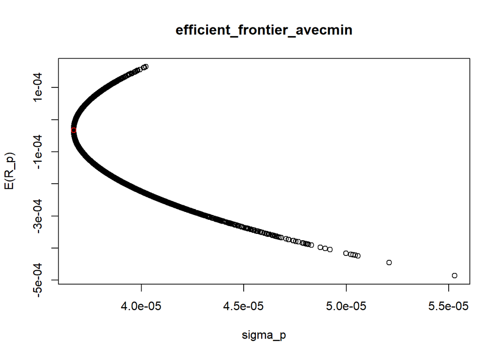

```r
points(x[index_min_sigma_p],y[index_min_sigma_p],col='red')
```

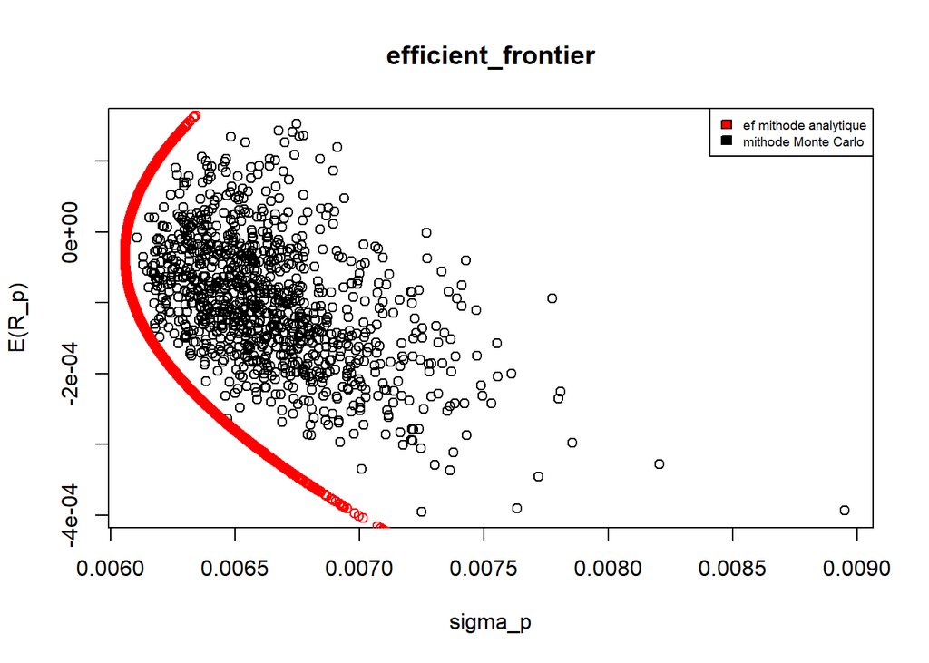

```r
#----------
plot(xx, yy,
     main="efficient_frontier",
     xlab="sigma_p",
     ylab="E(R_p)",
     #ylim = c(-1e-04 ,max(y))
     )
points(sqrt(x), y,col='red')
legend("topright",
       c("ef mithode analytique","mithode Monte Carlo"),
       fill=c("red","black"),
       cex=0.6)
```